# Hypothesis Testing & Effect Size

## Did Community Policing Actually Improve Response Times?

The city of Westbrook implemented a new community policing program in January. The police chief claims the program has improved emergency response times. Before the program, the average response time was **8.2 minutes** with a standard deviation of **1.5 minutes**. You’ve collected data from 20 randomly selected emergency calls after the program started.

Your editor wants to know two things: Is the improvement real? And is it big enough to matter?

### Task 1: Load the tidyverse

```r
library(tidyverse)
```

### Task 2: Set up the data and the hypotheses (2 points)

Before we run any tests, we need to state our hypotheses. The null hypothesis is what we assume to be true until we have evidence otherwise — like “innocent until proven guilty.” Fill in the REPLACE_ME values.

**Alternative Hypothesis (H₁):** The new program has been effective in decreasing call time.

```r
# Response times (in minutes) after the community policing program
response_times <- c(
  7.8, 8.1, 7.5, 7.9, 8.3,
  7.6, 7.4, 8.0, 7.7, 7.8,
  8.2, 7.3, 7.9, 7.5, 8.1,
  7.6, 7.8, 7.4, 7.7, 7.9
)

# Known baseline (before the program)
baseline_mean <- 8.2
baseline_sd <- 1.5

# Create a tibble
response_data <- tibble(
  call_number = 1:20,
  response_time = response_times
)

response_data
```

```
## # A tibble: 20 × 2
##    call_number response_time
##          <int>         <dbl>
##  1           1           7.8
##  2           2           8.1
##  3           3           7.5
##  4           4           7.9
##  5           5           8.3
##  6           6           7.6
##  7           7           7.4
##  8           8           8
##  9           9           7.7
## 10          10           7.8
## 11          11           8.2
## 12          12           7.3
## 13          13           7.9
## 14          14           7.5
## 15          15           8.1
## 16          16           7.6
## 17          17           7.8
## 18          18           7.4
## 19          19           7.7
## 20          20           7.9
```

### Task 3: Calculate summary statistics (1 point)

Let’s see what the new response times look like. Replace the REPLACE_ME values.

```r
summary_stats <- response_data |>
  summarize(
    sample_size = n(),
    sample_mean = mean(response_time),
    sample_sd = sd(response_time),
    standard_error = sample_sd / sqrt(sample_size)
  )

summary_stats
```

```
## # A tibble: 1 × 4
##   sample_size sample_mean sample_sd standard_error
##         <int>       <dbl>     <dbl>          <dbl>
## 1          20        7.78     0.281         0.0628
```

**Answer this question:** The sample mean is lower than the baseline of 8.2 minutes. How much lower? Does that seem like a meaningful improvement to you, just based on the numbers? What would you want to know before deciding?

That does seem like an improvement because the average call time has lowered from the 8.2 minute baseline to 7.775, and the standard deviation has gotten smaller, meaning there is a lower chance the time it takes for the police to respond will be very different to the average.

### Task 4: Perform a one-sample t-test (2 points)

Now we formally test the police chief’s claim. Since we’re testing whether response times *decreased*, we use a one-sided test (`alternative = "less"`). Replace the REPLACE_ME with the baseline mean we’re comparing against.

```r
# Set our significance level
alpha <- 0.05

# Perform the t-test
t_test_result <- t.test(
  response_data$response_time,
  mu = 8.2,
  alternative = "less"
)

t_test_result
```

```
##
##  One Sample t-test
##
## data:  response_data$response_time
## t = -6.7701, df = 19, p-value = 9.097e-07
## alternative hypothesis: true mean is less than 8.2
## 95 percent confidence interval:
##      -Inf 7.883548
## sample estimates:
## mean of x
##     7.775
```

### Task 5: Interpret the t-test results (2 points)

Let’s pull out the key numbers. Look at the p-value: is it less than our alpha of 0.05?

```r
# Extract key values
p_value <- t_test_result$p.value

results <- tibble(
  `Baseline mean` = paste(baseline_mean, "minutes"),
  `New mean` = paste(round(summary_stats$sample_mean, 2), "minutes"),
  `Difference` = paste(round(baseline_mean - summary_stats$sample_mean, 2), "minutes"),
  `p-value` = round(p_value, 6),
  `Significant?` = if_else(p_value < alpha, "Yes - reject null hypothesis", "No - fail to reject")
)

results
```

```
## # A tibble: 1 × 5
##   `Baseline mean` `New mean`   Difference   `p-value` `Significant?`
##   <chr>           <chr>        <chr>            <dbl> <chr>
## 1 8.2 minutes     7.78 minutes 0.42 minutes  0.000001 Yes - reject null hypothe…
```

**Answer this question:** Based on the p-value, can we reject the null hypothesis? What does this tell the police chief — and what does it NOT tell him?

It is rejecting the null hypothesis which means the program is moving in the right direction. It doesn’t tell him the standard deviation- likelihood of the response time being close to the average.

### Task 6: Visualize the results

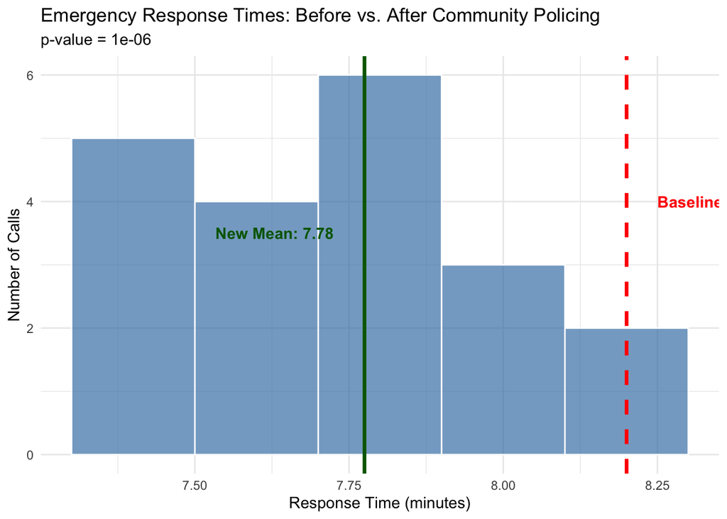

```r
ggplot(response_data, aes(x = response_time)) +
  geom_histogram(binwidth = 0.2, fill = "steelblue", color = "white", alpha = 0.7) +
  geom_vline(xintercept = baseline_mean, color = "red", linetype = "dashed", size = 1.2) +
  geom_vline(xintercept = summary_stats$sample_mean, color = "darkgreen", size = 1.2) +
  annotate("text", x = baseline_mean + 0.05, y = 4,
           label = paste("Baseline:", baseline_mean),
           color = "red", hjust = 0, fontface = "bold") +
  annotate("text", x = summary_stats$sample_mean - 0.05, y = 3.5,
           label = paste("New Mean:", round(summary_stats$sample_mean, 2)),
           color = "darkgreen", hjust = 1, fontface = "bold") +
  labs(
    title = "Emergency Response Times: Before vs. After Community Policing",
    subtitle = paste0("p-value = ", round(p_value, 6)),
    x = "Response Time (minutes)",
    y = "Number of Calls"
  ) +
  theme_minimal()
```

### Task 7: Calculate the effect size (3 points)

The t-test told us the improvement is statistically significant — it’s real, not due to chance. But is it *meaningful*? That’s what effect size measures. We’ll calculate **Cohen’s d**, which tells us how large the difference is in standard deviation units.

The formula is: d = (baseline mean - sample mean) / baseline standard deviation

Replace the REPLACE_ME values.

```r
effect_size <- (baseline_mean - summary_stats$sample_mean) / baseline_sd

effect_size_interpretation <- case_when(
  abs(effect_size) < 0.2 ~ "Negligible",
  abs(effect_size) < 0.5 ~ "Small",
  abs(effect_size) < 0.8 ~ "Medium",
  TRUE ~ "Large"
)

tibble(
  `Cohen's d` = round(effect_size, 3),
  `Interpretation` = effect_size_interpretation,
  `Difference in minutes` = round(baseline_mean - summary_stats$sample_mean, 2),
  `Difference in seconds` = round((baseline_mean - summary_stats$sample_mean) * 60, 0)
)
```

```
## # A tibble: 1 × 4
##   `Cohen's d` Interpretation `Difference in minutes` `Difference in seconds`
##         <dbl> <chr>                            <dbl>                   <dbl>
## 1       0.283 Small                             0.42                      25
```

**Answer this question:** The result is statistically significant, but the effect size is small. In practical terms, the improvement is about 25 seconds per call. The police chief is claiming success. Would you write a story saying the program works? How would you frame the findings honestly — acknowledging both that the improvement is real AND that it’s small?

I would write a story about the new program and frame it as hope for more progress in the future. I would present the results and say so far, the new program has reduced call time by 25 seconds, the police department is trending in the right direction, but steps still need to be made to further reduce the time.

### Task 8: The journalist’s framework (5 points)

The videos you watched describe two questions you need to ask about any statistical result:

1. **Is it statistically significant?** (Is the result unlikely to be due to chance?)
2. **Is it meaningfully significant?** (Is the effect large enough to matter?)

Apply this framework to the community policing data:

**Question 1:** Write 1-2 sentences answering whether the result is statistically significant and how you know.

**Question 2:** Write 1-2 sentences answering whether the result is meaningfully significant. Consider: the program cost the city $2 million to implement. Is a 25-second improvement in response times worth that investment? What context would you need to answer that question?

When dealing with emergency response, 25 seconds can be dthe differenve between someone dying or making it out alive, however, in this case with the response time initially being so bad I don’t think its largely meaningful as there still needs to be more improvement. For the amount of money spent on 25 seconds, there still needs to be more done.

**Question 3:** Write a headline and a 2-3 sentence lede for a story about these findings. Your text should accurately reflect both the statistical significance and the effect size — don’t let the police chief’s framing drive the story if the data tells a more nuanced one.

New Police Program Reduces Call Time Averages– Still More Needs to be Done.

In January, Westbrook Police implemented a new $2 million community policing program in January the police chief announced has improved emergency response times.

When you are finished, save your work, switch to GitHub Desktop, then add, commit and push your changes to GitHub and submit the URL of the notebook in ELMS.